# OCN 750 HW 4 – Amphibian Roadkill

##### Fit the same model with quasipoisson, and with a negative binomial distribution.

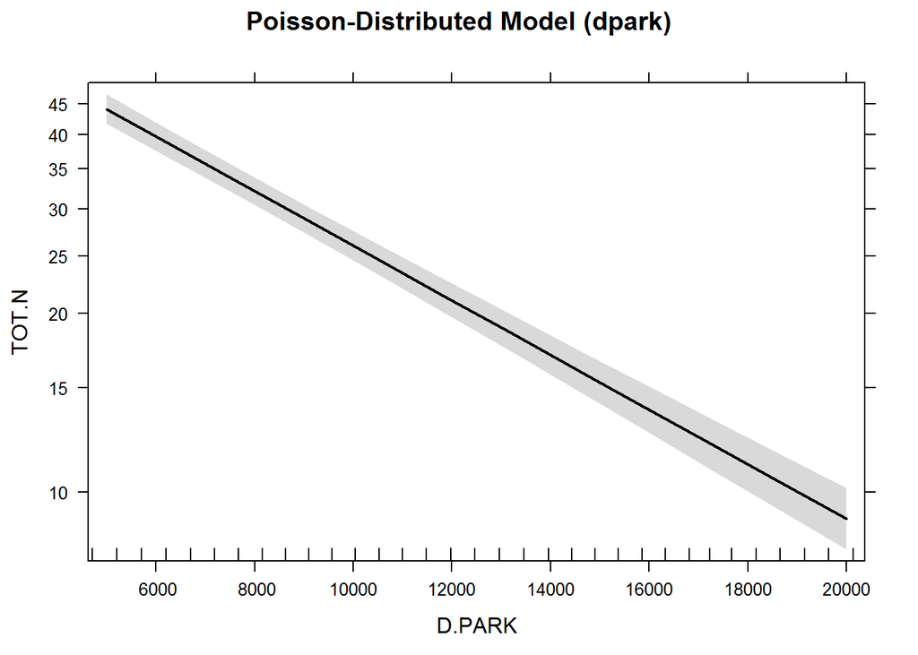

```r
#create your Quasi - Poisson GLM using the square-root transformed values
qpoipark = glm(TOT.N ~ D.PARK, data = roadkill, family = quasipoisson)

#Create the negative binomial model
require(MASS)
negbpark = glm.nb(TOT.N ~ D.PARK, data = roadkill)

#Plot them all together
par(mfrow = c(3,1))
#This looks very different from the example in class.
plot(allEffects(poipark), main = "Poisson-Distributed Model (dpark)", col = "darkseagreen1")
```

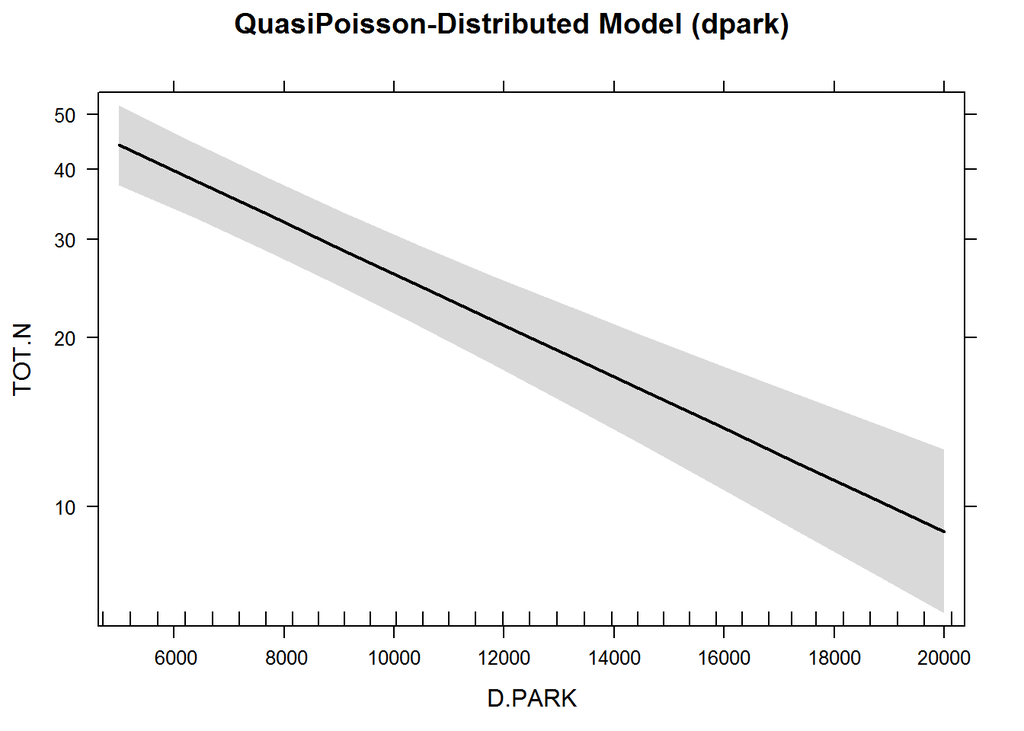

```r
plot(allEffects(qpoipark), main = "QuasiPoisson-Distributed Model (dpark)", col = "darlseagreen2")
```

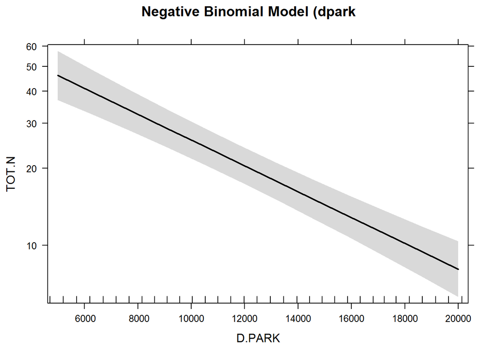

```r
plot(allEffects(negbpark), main = "Negative Binomial Model (dpark", col = "darkseagreen3")
```

##### Do appropriate hypothesis tests on these models.

```r
#A bootstrapping may be more approriate, but here we do a  Likelhihood Ratio Test (X2 distributed).
#A t-test would assume normal error (analogous to Wald test).
#The LRT is quickly summarized by Anova()

#Here I run the test and pin it to a new data frame. All three indicate significance.
LRT = cbind(Anova(poipark)[1],
Anova(qpoipark)[1],
Anova(negbpark)[1])
names(LRT)[1:3] = c("poisson", "qpoisson", "negbinom")
LRT
```

```
##         poisson qpoisson negbinom
## D.PARK 680.5468 89.19183  100.703
```

##### How big is overdispersion based on the quasipoisson?

```r
#dispersion  parameter  function - this way you can quickly quantify Phi based on whatever glm you used.
overdis = function(model)   {
        sum(residuals(model,    type    = "pearson")^2)/(length(model$y) - length(model$coefficients))
}
overdis(qpoipark) #Phi is quite high
```

```
## [1] 7.629755
```

##### What is the theta parameter for the negative binomial?

```r
theta = overdis(negbpark)
theta #much smaller
```

```
## [1] 1.011433
```

##### Does overdispersion affect the conclusions you would draw from this analysis?

```r
#Our Phi value was pretty high even for the QPoisson.
#Looks like the negative binomial model successfully accounts for the overdispersion, as the Theta value is well under 1.5.
```

##### Now fit a Poisson model that adds in the other two predictors, URBAN (squareroot transformed) and D.WAT.RES.

```r
poi.urwapa = glm(TOT.N ~ urb_sqrt + D.WAT.RES + D.PARK, data = roadkill, family = "poisson")
summary(poi.urwapa)
```

```
##
## Call:
## glm(formula = TOT.N ~ urb_sqrt + D.WAT.RES + D.PARK, family = "poisson",
##     data = roadkill)
##
## Deviance Residuals:
##     Min       1Q   Median       3Q      Max
## -6.4582  -1.9345  -0.5904   1.3783   7.1839
##
## Coefficients:
##               Estimate Std. Error z value Pr(>|z|)
## (Intercept)  4.298e+00  7.196e-02  59.734  < 2e-16 ***
## urb_sqrt    -5.345e-02  2.145e-02  -2.491   0.0127 *
## D.WAT.RES    3.729e-04  9.053e-05   4.119 3.81e-05 ***
## D.PARK      -1.228e-04  5.499e-06 -22.334  < 2e-16 ***
## ---
## Signif. codes:  0 '***' 0.001 '**' 0.01 '*' 0.05 '.' 0.1 ' ' 1
##
## (Dispersion parameter for poisson family taken to be 1)
##
##     Null deviance: 1071.4  on 51  degrees of freedom
## Residual deviance:  361.7  on 48  degrees of freedom
## AIC: 609.09
##
## Number of Fisher Scoring iterations: 5
```

##### What is effect size of the 3 different predictors, i.e. how much does # roadkills change as these predictors vary? How do residuals vs. fitted values and residuals vs. predictors look (you can just use deviance or pearson residuals, as they are more appropriate for GLMs)? Do appropriate (marginal) likelihood ratio tests for each of the three predictors.

```r
#The effect of each of these predictors is given by the ANOVA.
Anova(poi.urwapa) #it appears that Dpark is still the highest influence upon the model.
```

```
## Analysis of Deviance Table (Type II tests)
##
## Response: TOT.N
##           LR Chisq Df Pr(>Chisq)
## urb_sqrt      6.43  1    0.01125 *
## D.WAT.RES    16.78  1  4.208e-05 ***
## D.PARK      595.27  1  < 2.2e-16 ***
## ---
## Signif. codes:  0 '***' 0.001 '**' 0.01 '*' 0.05 '.' 0.1 ' ' 1
```

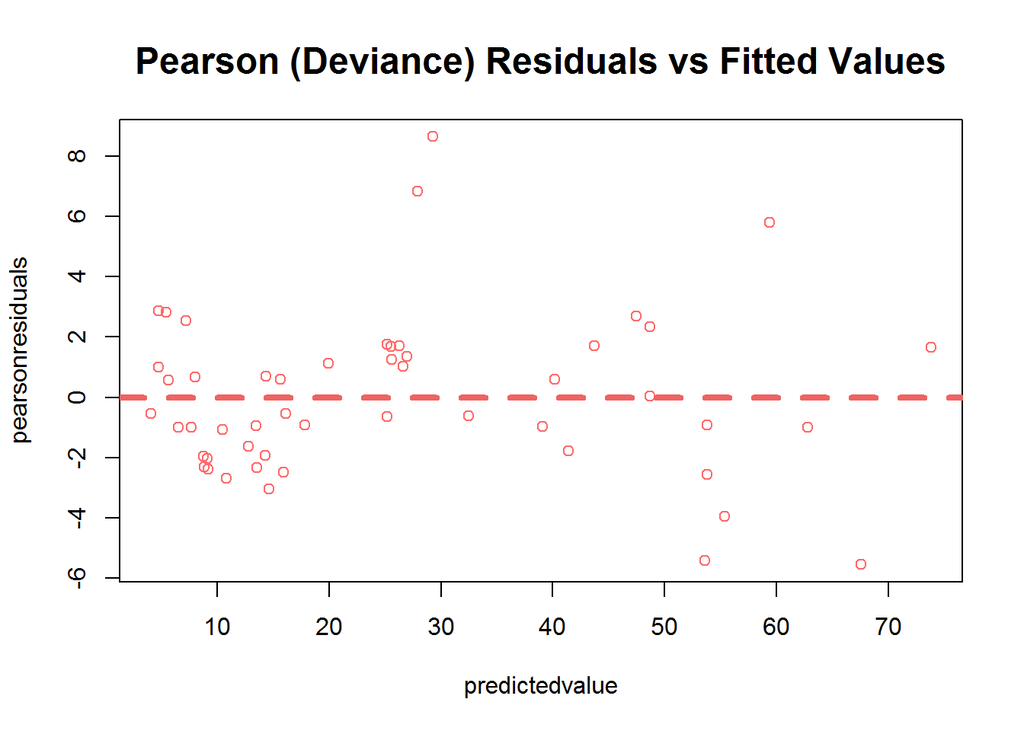

```r
#Plot of fitted values vs. deviance (Pearson) residuals
plot(residuals(poi.urwapa,  type    = "pearson")    ~ fitted(poi.urwapa),   ylab    = "pearson  residuals", xlab    = "predicted    value", main = "Pearson (Deviance) Residuals vs Fitted Values", cex.main = 1.5, col = "indianred1")
abline(h    = 0,    lty = 2,    lwd = 4,    col = "indianred2")
```

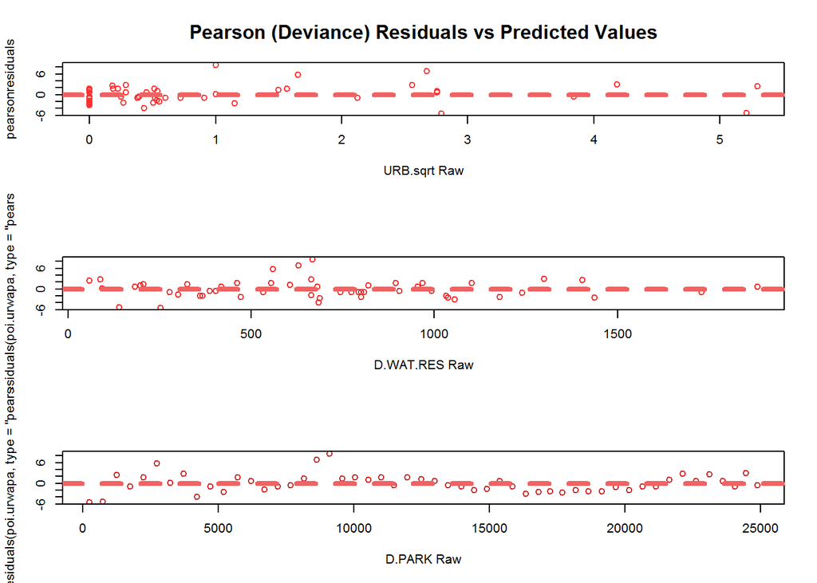

```r
#Plot of sqrt-transformed predictor values vs. deviance (Pearson) residuals for three variables
par(mfrow = c(3,1))

#raw urban values
plot(residuals(poi.urwapa,  type  = "pearson")  ~ roadkill$urb_sqrt,    ylab    = "pearson  residuals", xlab    = "URB.sqrt Raw", main = "Pearson (Deviance) Residuals vs Predicted Values", cex.main = 1.5, col = "firebrick1")
abline(h    = 0,    lty = 2,    lwd = 4,    col = "indianred2")

#raw dwat values
plot(residuals(poi.urwapa,  type  = "pearson") ~ roadkill$D.WAT.RES, xlab = "D.WAT.RES Raw", col = "firebrick2")
abline(h  = 0,  lty = 2,    lwd = 4,    col = "indianred2")

#raw dpark values
plot(residuals(poi.urwapa,  type  = "pearson") ~ roadkill$D.PARK, xlab = "D.PARK Raw", col = "firebrick3")
abline(h  = 0,  lty = 2,    lwd = 4,    col = "indianred2")
```

```r
dev.off()
```